| Director: | Trevor Pugh, PhD, FACMG |  |  |  |  |
| --- | --- | --- | --- | --- | --- |
| Phone: | 647-468-7844 |  |  |  |  |
| Main contact: | Iain Bancarz, PhD |  |  |  |  |
| Email: | report.inquiries@oicr.on.ca |  |  |  |  |
| Hours of Operation: | Mon-Fri, 9:00AM - 5:00PM |  |  |  |  |

| Ontario Institute for Cancer Research |  |  |
| --- | --- | --- |
| c/o Tissue Portal Sample Receiving MaRS Centre |  |  |
| West Tower 661 University Avenue, Suite 6-46 |  |  |
| Toronto, Ontario, Canada, M5G 0A3 |  |  |
| **CAP:** 8381376 | **ACDx:** 0730 | **CLIA:** 99D2270792 |

# Clinical Research Report

## Patient & Physician

[output not shown]

## Case Overview

| Assay: | plasma Whole Genome Sequencing (pWGS) - 30X (v3.0) |  |  |
| --- | --- | --- | --- |
| Primary cancer: | Pancreatic adenocarcinoma |  |  |
| Study: | PRSPR | Patient Study ID: | PSP-009-071,12165_196547 |
| Patient LIMS ID: | PANX_1698 | WGS Report ID: | PRSPR-712 |
| Requisition Approved: | 2024-06-04 | Plasma Sample ID: | PSP-009-071_plasma |
| Date of Report: | 2026-06-04 | pWGS Report ID: | PRSPR-PLAS-713-v1 |

## Summary

### Cell-free DNA tumour burden: Detected

| Mutational sampling analysis: | ctDNA DETECTED |
| --- | --- |

## SAMPLE QC

| Type of Specimen: | Plasma | Candidate SNVs: | 21,000 |
| --- | --- | --- | --- |
| Median Insert Size (bp): | 162 | Coverage (mean): | 102.0 |

## Mutational Sampling

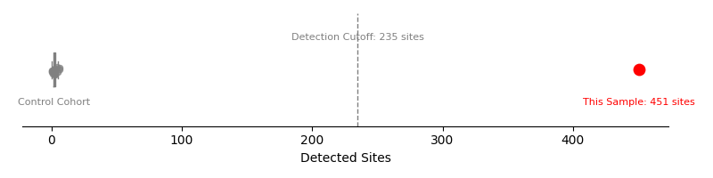

| 105,414 | 560 | 0.53% |
| --- | --- | --- |

Plasma whole genome sequencing (pWGS) is a comprehensive next generation sequencing assay for the detection of minimal residual disease. Plasma libraries were prepared using the KAPA Hyper Prep kit with DNA extracted from cfDNA. Paired-end sequencing was performed using the illumina NovaSeq X Plus v1.3 technology. Alignments were performed using [bwa](https://bio-bwa.sourceforge.net/) mem2 (2.2.1) against reference genome [GRCh38.p12](https://www.ncbi.nlm.nih.gov/assembly/GCF_000001405.38/) and processed with [Picard](https://gatk.broadinstitute.org/hc/en-us/articles/360037052812-MarkDuplicates-Picard-) (2.21.2), which includes duplicate marking. Reads were filtered for ctDNA likelihood and matches with primary tumour by [MRDetect](https://pubmed.ncbi.nlm.nih.gov/32483360/) (1.0). The sample is compared against a control cohort of Healthy Blood Controls (HBCs) sequenced and processed at OICR using the same procedure as any tested plasma sample.

Assay results were collated into the report document by [Djerba](https://github.com/oicr-gsi/djerba) (1.11.11) using PWGS pipeline 3.0.

Based on a minimum coverage of 30X, the sensitivity is 93%. The limit of detection is 0.4% ctDNA.  
Minimal Residual Disease testing by Plasma whole genome sequencing encompasses all genomic regions in a specimen. Gene annotation is not performed in this assay and variants are not classified (e.g. by pathogeneity).  
This test was developed and its performance characteristics determined by OICR Genomics. It has not been cleared or approved by the US Food and Drug Administration.

[output not shown]

## APPENDIX

**Minimal Residual Disease (MRD):** malignant cells that share genetics with the original tumour cells but that remain in a patient who achieves remission (*see* DOI: [10.1038/nrc.2017.125](https://pubmed.ncbi.nlm.nih.gov/29376520/)). Detection of minimal residual disease is not conclusively associated with prognosis. Treatment choices should be made on a case-by-case basis with the treating physician.  
**circulating tumour DNA (ctDNA):** DNA that comes from dying cancerous cells and is found in the bloodstream. Here, a marker for MRD.  
**Coverage:** the mean number of bases covering each sequenced base. Minimum coverage threshold is 30x (with a target of 40x).  
**Insert Size:** the length in base pairs of the DNA between adapters, affected by both biology and laboratory.  
**Mutational Sampling Analysis:** sampling and sequencing cell-free DNA in plasma to search for single nucleotide variants matching the primary tumour.  
**Candidate SNVs:** the number of single nucleotide variants from the primary tumour that can be used for ctDNA detection. If the number of candidate SNVs is too low (below 4,000), mutational sampling analysis is unreliable.  
**Mutant/Checked Read Percentage:** the percentage of reads with primary tumour matches divided by the total checked reads covering candidate sites. When ctDNA is detected, it may be an estimate of the fraction of ctDNA in the blood, but if ctDNA is not detected, it is an estimate of sequencing artefact matches.